# DataScienceProjects

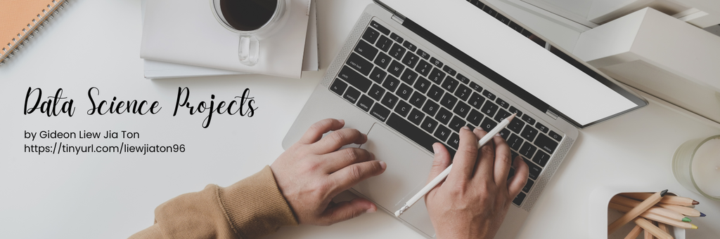

This content page demonstrates my data science projects and skills such as python and SQL. If you think I am the right candidate for the data job role, please contact me.

Email: liewjiaton_96@hotmail.my

LinkedIn: www.linkedin.com/in/gideon-jia-ton-liew-442174194

Website: https://tinyurl.com/liewjiaton96

## 1) Exploratory Data Analysis (IMDb Movie Dataset)

- Obtain data from data source
- Clean data to machine readable format
- Explore data patterns using seaborn and matpoltlib
- Train model to forecast IMDB_Rating and Gross
- Interpret data patterns to solve Task 1 and Task 2

Conclusion: To get good rating and gross amount, movie cast is the most important especially supporting roles. Second, the public reputation of director is another huge factor. Lastly, no. of votes shall give a very good indication.

Project Link: https://liewjiaton96.github.io/DataScience/EDA_IMDb_Movie.html

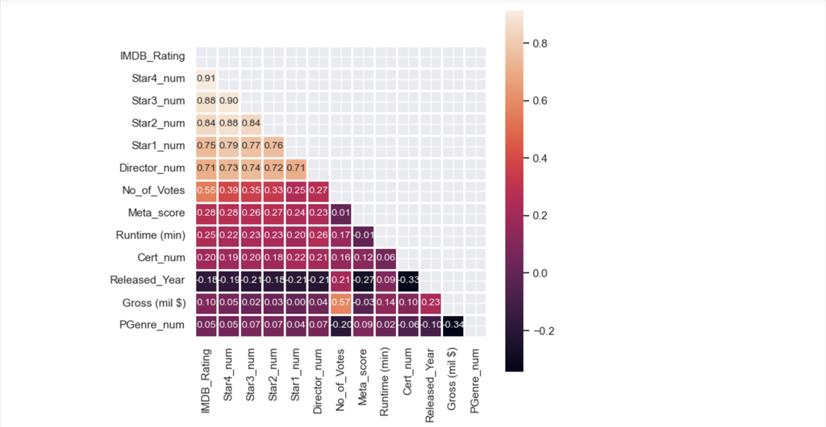

## 2) Extract Transform Load Data to BigQuery (Chicago Crime Data)

- Extract CSV format file in a zip file (CrimesData.csv.zip)
- Transform all column names and date format
- Load data into BigQuery

Conclusion: Data have been Extract, Transform, Load into BigQuery. We may check in BigQuery and query data from Looker Studio for visualisation.

Project Link: https://colab.research.google.com/drive/1t0CJGLAHTbdORNIV4jLLLtywp-tDnzUC?usp=sharing

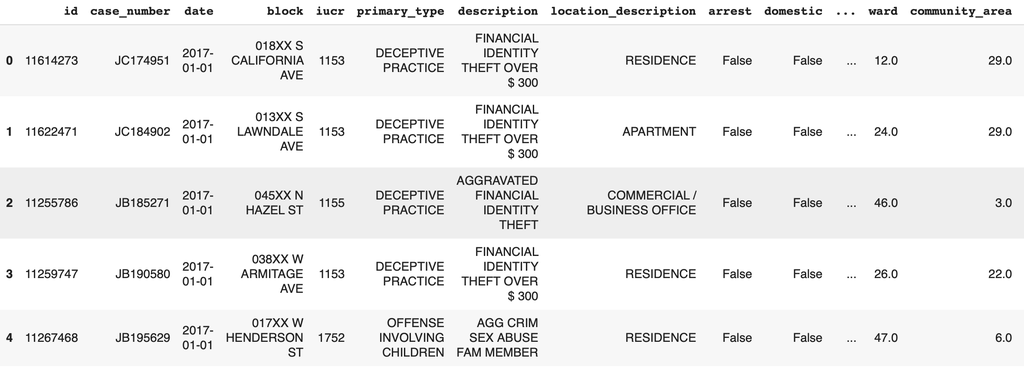

## 3) Data Visualisation in Looker Studio (Chicago Crime Dashboard)

- Overview: From 2017 to 2021, total Chicago crime cases were 1.2 millions with arrest rate 18.17%. Almost one out of five cases has been solved. A significant drop of cases was noticed since 2020.
- Time Trend: More cases occurred before COVID (2017 to 2019), during hot seasons (spring, autumn) and in the day (6am to 8pm)
- Hotspots: Theft and criminal damage often occur on the streets while battery mostly happened in apartments and residence areas.

Conclusion: Foreigners may enquire safety information from city councils or police before moving into a new area.

Project Link: https://drive.google.com/file/d/1AH5IQB3gMKzf544mGUa4Fd9loobZQ_WG/view?usp=sharing

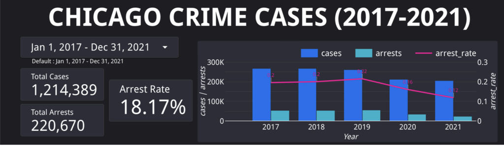

## 4) Web Scraping, Natural Langauge Processing, Sentiment Analysis (Restaurant Review Analysis)

- Scrap data from webpage using Beautiful Soup
- Perform natural language processing on Review data
- Analyze sentiment of Review data using nltk.sentiment

Conclusion: Review sentiments have weak positive correlation to the rating from Tripadvisor users. This indicates that a single rating can not represent user's full expression and review sentiments should be taken into consideration when picking a restaurant.

Project Link: https://liewjiaton96.github.io/DataScience/Restaurant_Review_Analysis

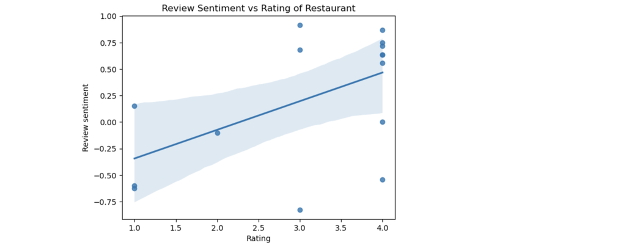